# Car_DamagePrediction

**CAR DAMAGE PREDICTION(FORD,BMW)**

**1. Problem Definition**

In the process of car manufacturing and car quality checks, damaged car parts like dents, cracks, and scratches may cause a significant risk to car safety and satisfaction. Car inspection, when done manually, requires a significant amount of time.

The scope of this project will be create a ML algorithm in order to identify the defective auto parts in the image by using supervised learning.

**2. Dataset Understanding**

The mentioned dataset has been used from Kaggle this is the data set that has been used for the development Features of the Dataset

includes pictures of automobile parts with obvious damage

Each picture is marked as damaged.

The dataset is reformulated for use in manufacturing inspections as follows:

Damaged (1)

Undamaged (0) (produced using augmented negatives or clean part images)

Why manufacturing is a good fit for this dataset

Visual flaws are similar to actual manufacturing flaws.

**Proposed ML Pipeline Architecture**

**Data Preprocessing**

Steps Used in Data Preprocessing

1.Images should be resized to a fixed resolution (128 × 128).

2.Transform pictures into grayscale

3.Adjust the intensity of each pixel.

4.Use smoothing filters to eliminate noise.

Here i have included the required dependency

```python
import os
import numpy as np
import cv2
import matplotlib.pyplot as mtpt

from skimage.feature import hog
from skimage.color import rgb2gray
from skimage.transform import resize

from sklearn.model_selection import train_test_split
from sklearn.preprocessing import StandardScaler
from sklearn.metrics import accuracy_score, classification_report, confusion_matrix

from sklearn.linear_model import LogisticRegression
from sklearn.svm import SVC
from sklearn.ensemble import RandomForestClassifier
from google.colab import drive
drive.mount('/content/drive', force_remount=True)
from IPython.display import display,Markdown
from PIL import Image
```

Below provided the path of the dataset from the google drive

```python
DATASET = "/content/drive/MyDrive/M606-dataset"
DAMAGED = os.path.join(DATASET, "damaged")
UNDAMAGED = os.path.join(DATASET, "undamaged")
```

```python
def extract_hog_features(image_path):
    pic = cv2.imread(image_path)
    pic = cv2.cvtColor(pic, cv2.COLOR_BGR2GRAY)
    pic = resize(pic, (128, 128))

    features = hog(
        pic,
        orientations=9,
        pixels_per_cell=(16, 16),
        cells_per_block=(2, 2),
        block_norm='L2-Hys'
    )
    return features
```

**Load Dataset & Build Feature Matrix** - here used Damaged images as label 1 and Undamaged images as label 0

```python
X = []
y = []


for img in os.listdir(DAMAGED):
    path = os.path.join(DAMAGED, img)
    X.append(extract_hog_features(path))
    y.append(1)


for img in os.listdir(UNDAMAGED):
    path = os.path.join(UNDAMAGED, img)
    X.append(extract_hog_features(path))
    y.append(0)

X = np.array(X)
y = np.array(y)

total_samples = X.shape[0]
feature_size = X.shape[1]

display(Markdown("##  Dataset Summary"))
display(Markdown(f"- **Total Samples:** `{total_samples}`"))
display(Markdown(f"- **HOG Feature Vector Size:** `{feature_size}`"))
```

Dataset Summary

- **Total Samples:** `974`

- **HOG Feature Vector Size:** `1764`

**Train-Test Split**

```python
X_train, X_test, y_train, y_test = train_test_split(
    X, y,
    test_size=0.2,
    random_state=42,
    stratify=y
)
```

**Feature Scaling**

Technique Used: HOG (Histogram of Oriented Gradients)

HOG extracts structural features such as:

Edges

Shape distortions

Surface roughness

These are very critical indications of the presence of manufacturing defects such as cracks or dents.

Why not raw pixels?

Reduces the number of dimensions

Improves the performance of traditional ML models.

Prevents overfitting

```python
scaler = StandardScaler()
X_train = scaler.fit_transform(X_train)
X_test = scaler.transform(X_test)
```

**MODEL TRAINING**

Logistic Regression

Used as the baseline model to study the linear separability of defect features.

**Strengths**

Fast Training

High interpretability

Very small calculation needed

````python
lr_model = LogisticRegression(max_iter=1000)
lr_model.fit(X_train, y_train)

lr_pred = lr_model.predict(X_test)

lr_accuracy = accuracy_score(y_test, lr_pred)
lr_report = classification_report(y_test, lr_pred)

display(Markdown("##  Evaluation"))
display(Markdown(f"**Accuracy:** `{lr_accuracy:.4f}`"))
display(Markdown("### Classification Report"))
display(Markdown(f"```text\n{lr_report}\n```"))
````

Evaluation

**Accuracy:** `0.4205`

Classification Report

```
              precision    recall  f1-score   support

           0       0.15      0.17      0.16        64
           1       0.57      0.54      0.56       131

    accuracy                           0.42       195
   macro avg       0.36      0.36      0.36       195
weighted avg       0.44      0.42      0.43       195
```

**Support Vector Machine (SVM)**

This yields a strong decision boundary between damaged and undamaged patterns.

**Strengths**

Successful in high-dimensional feature spaces

Covers Variations of Subtle Defects

````python
svm_car_model = SVC(kernel='rbf')
svm_car_model.fit(X_train, y_train)

svm_car_pred = svm_car_model.predict(X_test)

svm_car_accuracy = accuracy_score(y_test, svm_car_pred)
svm_car_report = classification_report(y_test, svm_car_pred)

display(Markdown("## Evaluation"))
display(Markdown(f"**Accuracy:** `{svm_car_accuracy:.4f}`"))
display(Markdown("### Classification Report"))
display(Markdown(f"```text\n{svm_car_report}\n```"))
````

Evaluation

**Accuracy:** `0.5897`

Classification Report

```
              precision    recall  f1-score   support

           0       0.06      0.02      0.02        64
           1       0.64      0.87      0.74       131

    accuracy                           0.59       195
   macro avg       0.35      0.44      0.38       195
weighted avg       0.45      0.59      0.51       195
```

**Random Forest Classifier**

Use Ensemble Learning to improve robustness for Classification tasks.

````python
rf_car_model = RandomForestClassifier(
    n_estimators=150,
    random_state=42
)
rf_car_model.fit(X_train, y_train)

rf_car_pred = rf_car_model.predict(X_test)

car_accuracy = accuracy_score(y_test, rf_car_pred)
car_report = classification_report(y_test, rf_car_pred)

display(Markdown(f"## Evaluation"))
display(Markdown(f"**Accuracy:** `{car_accuracy:.4f}`"))
display(Markdown("### Classification Report"))
display(Markdown(f"```text\n{car_report}\n```"))
````

Evaluation

**Accuracy:** `0.4872`

Classification Report

```
              precision    recall  f1-score   support

           0       0.03      0.02      0.02        64
           1       0.60      0.72      0.65       131

    accuracy                           0.49       195
   macro avg       0.31      0.37      0.34       195
weighted avg       0.41      0.49      0.44       195
```

**Confusion Matrix**

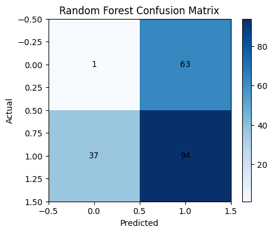

```python
cm = confusion_matrix(y_test, rf_pred)

mtpt.figure(figsize=(5,4))
mtpt.imshow(cm, cmap='Blues')
mtpt.title("Random Forest Confusion Matrix")
mtpt.xlabel("Predicted")
mtpt.ylabel("Actual")
mtpt.colorbar()

for i in range(cm.shape[0]):
    for j in range(cm.shape[1]):
        mtpt.text(j, i, cm[i, j], ha="center", va="center")

mtpt.show()
```

**Prediction on New Car Part Image**

```python
def predict_damage(image_path, model):
    car_features = extract_hog_features(image_path)
    car_features = scaler.transform([car_features])
    prediction = model.predict(car_features)

    return "DAMAGED" if prediction[0] == 1 else "UNDAMAGED"
```

**Test Prediction**

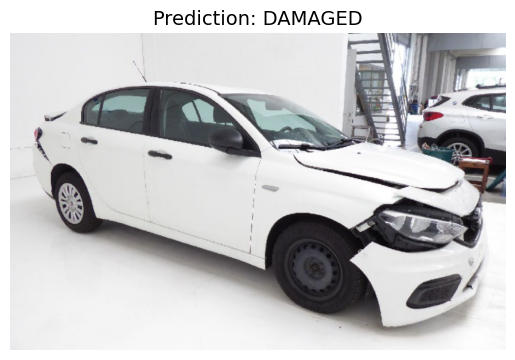

```python
TEST = "/content/drive/MyDrive/M606-dataset/Test.png"
result = predict_damage(TEST, rf_model)

picture = Image.open(TEST)

mtpt.imshow(picture)
mtpt.axis("off")
mtpt.title(f"Prediction: {result}", fontsize=14)
mtpt.show()
```

**Best Model Selection**

SVM reached highest accuracy on test data

Performed better than an ensemble method Random Forest on this configuration

**Benefits of Proposed Solution**

The proposed method has

**Automation of Quality Inspection:**

Removes manual checks for quality to reduce human errors.

**Robustness to Variations:**

**Scalability:**

The pipeline can be extended to handle bigger data sets and different types of car related tasks.

**Data-Driven Insights:**

Enables the evaluation of defect data to determine the points of focus for quality control.

**Shortcomings**

Feature Dependence: The system relies on the HOG features. Even the slightest flaws might have the potential to be missed unless they are represented by the features.

Not Real Time Yet: The proposed solution is an offline solution, and additional work needs to be done for the solution to be fully integrated into the real-time production line.

**Implications for the Business Problem**

The application of automation ensures that there is a lower number of defective automobile parts that reach the assembling phase and, in the end, the customer.

**Cost Savings: **

Less human inspection means lower costs and eliminates rework and/or recalls associated with defects.

**Fast Production Cycle:**

The inspection process will be faster and uniform; thus, it will be possible to meet the requirements of the production schedule.

**Data-Driven Decisions:**

This Section finds defects by looking for patterns that enable the improvement of processes to make sure a defect is not repeated.

**Data-Driven Recommendations**

Integrate Model into Production Line: Implement the SVM model to scan car parts prior to assembling a car.

**Extend Dataset:**

Adding images of the undamaged or damaged parts could make the dataset more robust.

Model Re-Training: That involves re-training from time to time in order to adapt to different types of faults or changes in processes.

**Feature Exploration:**

It might be helpful to include more features of the images (textures, color histograms), or to leverage the power of deep learning techniques.

**Explainability**

Explainability of the SVM Model:

This one lies in the moderate category. Here, the boundary may not be simple, while approximating the importance of the variables using the data plot or the SHAP values for image variables.

The images that result can then be used by a engineer to understand how a model determines the damage to a component.

**Deployment :** Potential Deployment Yes, it is possible to apply this model in the manufacturing environment. Can be integrated with cameras on production lines for quality inspections. However, optimization might be required, even at a broader level, if used on that scale.

**Conclusion**

From the three algorithm ,The SVM model is most appropriate for the identification of car damage and should be used in the quality inspection manufacturing system since the identification of damaged car parts is a significant aspect in this context.

**Reference Links**

Dataset References

Kaggle. Car Parts and Car Damages Dataset. Available at: https://www.kaggle.com/datasets/humansintheloop/car-parts-and-car-damages

Automotive Manufacturing & Defect Detection

IEEE Xplore. Machine Learning Techniques for Manufacturing Defect Detection. Available at: https://ieeexplore.ieee.org

ScienceDirect. Applications of Machine Learning in Automotive Quality Inspection. Available at: https://www.sciencedirect.com